# Введение в R

Dmitry Shubin

1. Посчитать

```r
35 + 777
```

```
## [1] 812
```

```r
13 * 47
```

```
## [1] 611
```

```r
675 * 15
```

```
## [1] 10125
```

```r
849 * 629
```

```
## [1] 534021
```

2. Умножим 11111111 само на себя

```r
11111111 * 11111111
```

```
## [1] 1.234568e+14
```

Теперь умножим на 1111111?

```r
#11111111 * 1111111?
```

Ошибка “Unexpected symbol” говорит о неверном вводе числа

3. Найдите площади прямоугольников с длинами (3,7,12,15, 20) и ширинами (2, 5,8,11,15) Зададим векторы длин и ширин

```r
length <-c(3, 7, 12, 15, 20)
width <-c(2, 5, 8, 11, 15)
```

Для нахождения площадей перемножим соответствующие значения длин и ширин

```r
square <- (length * width)
```

4. Постройте график этих длин и ширин

Используем функцию plot для построения точек и функцию lines для их соединения.

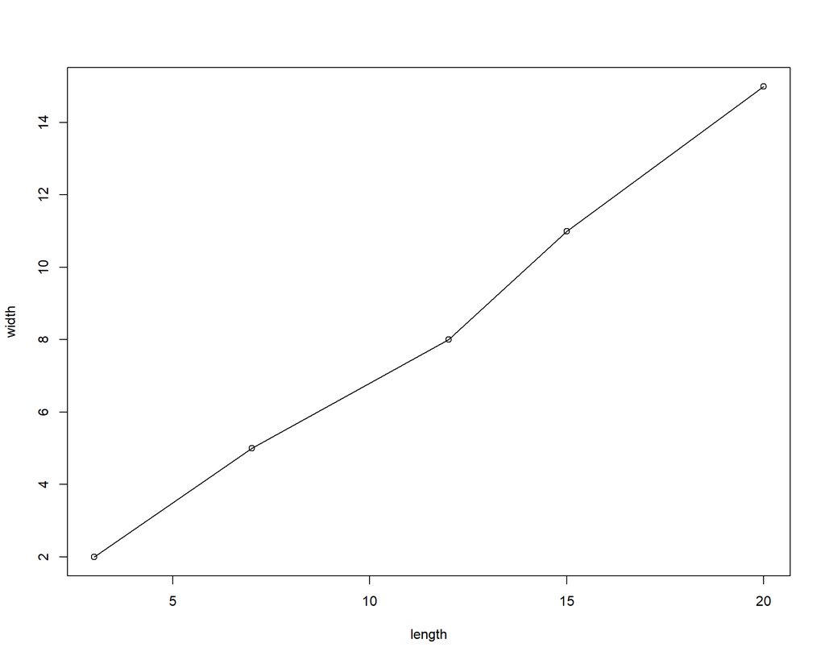

```r
plot(length, width)
lines(length, width)
```

5. Первокурсник Вася тратит очень много времени на домашнюю работу. 40 минут на математику, 40 на английский, 10 на физкультуру и 150 минут на программирование. Постройте график.

Отобразим график в виде столбчатой диаграммы. Для этого зададим вектор с именованными значениями затраченного времени. Затем построим столбчатую диаграмму по данным

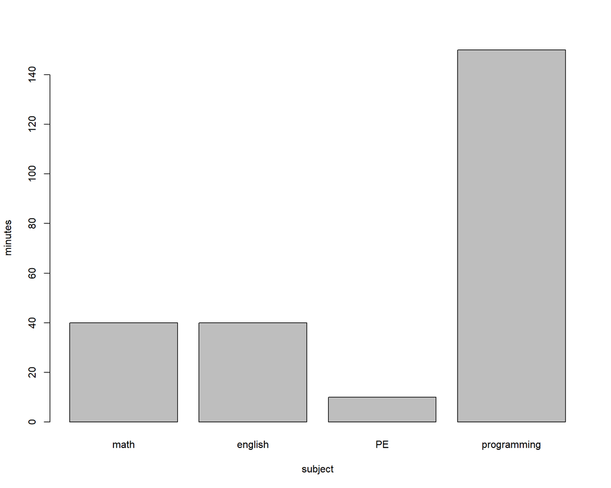

```r
homework <-c("math" = 40, "english" = 40, "PE" = 10, "programming" = 150)
barplot(homework, ylab = "minutes", xlab = "subject")
```

6. Напитки разливаются вручную в банки по 455 мл, количество налитого нормально распределено со средним значением 450 мл. и стандартным отклонением 4 мл. Чтобы смоделировать количество разлитого в 5 банок напишем следующий алгорим:

```r
drinks <-rnorm(5, mean = 450, sd = 4)
drinks
```

```
## [1] 454.1805 450.8174 452.7179 447.7164 450.3964
```

Сравнив с требуемым значением 455 мы можем наблюдать в какое количество бутылок налито больше положенного

```r
drinks > 455
```

```
## [1] FALSE FALSE FALSE FALSE FALSE
```

Смоделируйте разливание в 10000 бутылок и расчитайте вероятность перелива банки.

```r
drinks <-rnorm(10000, mean = 450, sd = 4)
mean(drinks > 455) * 100
```

```
## [1] 10.81
```